# Titanic EDA

Valentina Sanchez

## Exploratory Data Analysis of the Titanic Dataset

This is a cleaned version of the titanic (training) dataset [published on Kaggle](https://www.kaggle.com/datasets/jamesleslie/titanic-cleaned-data?select=train_clean.csv). Here is a quick statistical study.

```
##       Age           Cabin             Embarked              Fare
##  Min.   : 0.42   Length:891         Length:891         Min.   :  0.00
##  1st Qu.:22.00   Class :character   Class :character   1st Qu.:  7.91
##  Median :30.00   Mode  :character   Mode  :character   Median : 14.45
##  Mean   :29.45                                         Mean   : 32.20
##  3rd Qu.:35.50                                         3rd Qu.: 31.00
##  Max.   :80.00                                         Max.   :512.33
##      Name               Parch         PassengerId        Pclass
##  Length:891         Min.   :0.0000   Min.   :  1.0   Min.   :1.000
##  Class :character   1st Qu.:0.0000   1st Qu.:223.5   1st Qu.:2.000
##  Mode  :character   Median :0.0000   Median :446.0   Median :3.000
##                     Mean   :0.3816   Mean   :446.0   Mean   :2.309
##                     3rd Qu.:0.0000   3rd Qu.:668.5   3rd Qu.:3.000
##                     Max.   :6.0000   Max.   :891.0   Max.   :3.000
##      Sex                SibSp          Survived         Ticket
##  Length:891         Min.   :0.000   Min.   :0.0000   Length:891
##  Class :character   1st Qu.:0.000   1st Qu.:0.0000   Class :character
##  Mode  :character   Median :0.000   Median :0.0000   Mode  :character
##                     Mean   :0.523   Mean   :0.3838
##                     3rd Qu.:1.000   3rd Qu.:1.0000
##                     Max.   :8.000   Max.   :1.0000
##     Title            Family_Size
##  Length:891         Min.   : 0.0000
##  Class :character   1st Qu.: 0.0000
##  Mode  :character   Median : 0.0000
##                     Mean   : 0.9046
##                     3rd Qu.: 1.0000
##                     Max.   :10.0000
```

## Single Variable Analysis

#### Age Distribution of Passengers

The distribution of age among the passengers on the Titanic appears to be right-skewed, with the majority of passengers falling between the ages of 20 and 40. The count of passengers gradually decreases as age increases, with very few passengers over the age of 70.

The color legend for sex makes it easy to distinguish between the age distributions for males and females. The bars for males is blue, while the bars for females is pink or red. By comparing the height and color of the bars, we can quickly see how the age distribution differs between males and females on the Titanic.

Overall, this plot shows that the Titanic had a relatively young passenger population, with the majority of passengers being between the ages of 20 and 40, and that there were more males than females in every age group.

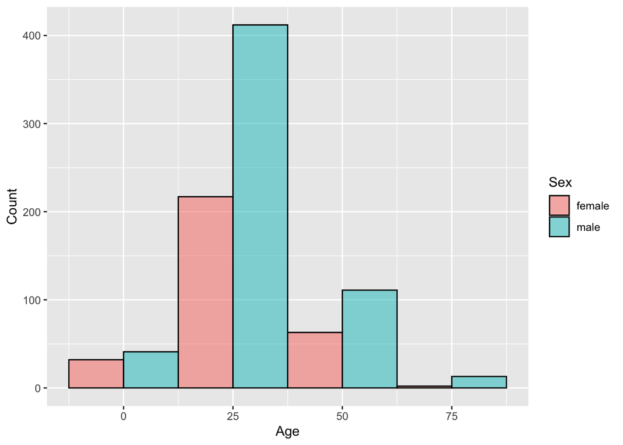

#### Passenger Class Distribution

The bar chart shows the number of passengers in each passenger class, with the x-axis representing the passenger class and the y-axis representing the count of passengers.

To add a color legend based on passenger class, we would use different colors for each passenger class, making it easy to see the distribution of passengers in each class. For example, using red for first class, green for second class, and blue for third class.

The resulting plot would show the distribution of passengers across the different classes, with the height of each bar representing the number of passengers in that class. We could see if there were more passengers in a particular class, and how many passengers were in each class relative to each other. The color legend would make it clear which bar represents which class, making it easy to compare the counts of passengers across different classes. Overall, this plot provides useful insights into the distribution of passengers across different classes in the Titanic dataset.

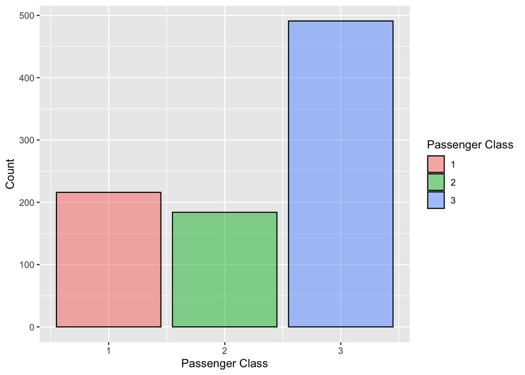

#### Fare Density Distribution

A density plot is a smoothed version of a histogram, where the x-axis represents the fare range and the y-axis represents the density of passengers within that fare range.

The resulting plot would show the distribution of fares for each passenger class, with a different color representing each class. We might expect to see that first-class fares are generally higher than second-class fares, which are generally higher than third-class fares. Additionally, we might see some overlap in the fare distributions between classes.

Overall, the density plot with a color legend based on passenger class would provide a clear and informative visualization of the fare distribution in the Titanic dataset, highlighting any differences or similarities in fare distributions between the different passenger classes.

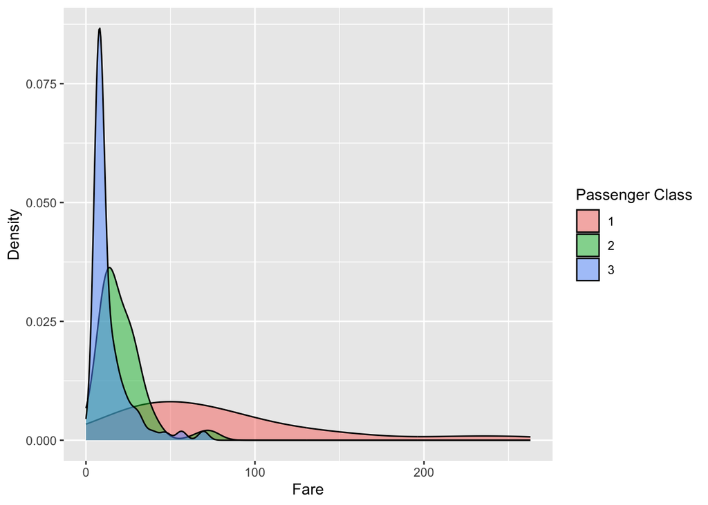

## Multi-Variable Variable Analysis

##### Compare variables to the value of interest (**Survived**)

#### Age vs Fare

The following graph shows a scatter of points, where each point represents a passenger on the Titanic. The position of the point on the x and y axis corresponds to the Age and Fare of the passenger, respectively. The color of the point indicates whether the passenger survived or not, with different colors assigned to each category. This plot can help to identify any patterns or trends in the data related to the Age, Fare, and survival status of the passengers.

One potential trend that may be observed is that passengers who paid higher fares may have had a higher chance of survival. This could be because passengers who paid more for their tickets were given priority access to lifeboats or were located in safer areas of the ship.

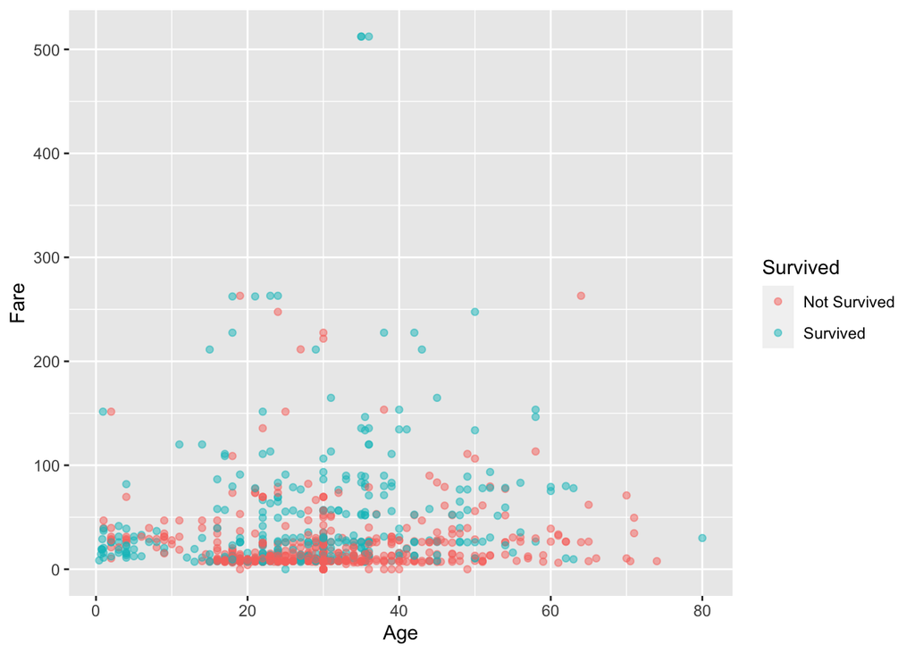

#### Gender vs Age

The box plot can help to identify any differences in the age distribution between male and female passengers who survived or did not survive. For example, there is not a significant difference in the age distribution of male passengers who survived, this could indicate that the male gender was given less priority and less access to lifeboats.

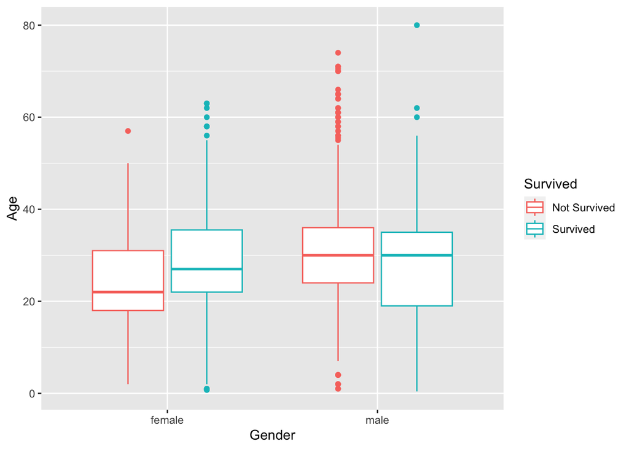